# Projection à 20 ans sans déversement et avec hypothèses sur évolution des débits

Marion Legrand & Etienne Prévost

2023-09-01

Pour commencer à regarder la sensibilité du modèle aux hypothèses d’évolution des débits, on réalise des projections à 20 ans sous 4 scénarios d’évolution des débits différents :

- Projection à 20 ans sans influence des débits. Scénario nommé “sans_Q” : on fait tourner les projections sans prise en compte de l’influence des débits sur les 20 ans de projection. Ce scénario consiste à mettre tous les débits à 0 afin d’avoir un modèle “toute chose égale par ailleurs”.

```r
if(scenario=="sans_Q"){
    for (t in (T+1):(T+20)){
      for (i in 1:iteration){
        L_Q_L_mont_P_20yr_cr[i,t]<-0
        L_Q_L_mont_A_20yr_cr[i,t]<-0
        L_Q_VB_mont_P_20yr_cr[i,t]<-0
        L_Q_VB_mont_A_20yr_cr[i,t]<-0
        L_Q_P_mont_P_20yr_cr[i,t]<-0
        L_Q_P_mont_A_20yr_cr[i,t]<-0

        L_Q_VB_deval_20yr_cr[i,t]<-0
        L_Q_MSL_mont_20yr_cr[i,t]<-0
        L_Q_MSL_deval_20yr_cr[i,t]<-0
      }
    }
}
```

- Les débits restent les mêmes sur la période de projection à 20 ans. Scénario nommé “identique” : durant les 20 ans de projection les débits sont suposés être les mêmes que ceux observés durant les 20 dernières années de la période rétrospective.

```r
if(scenario=="identique"){
  for(t in 1:20){
    for (i in 1:iteration){
      #Débit montaison Lempdes sur Alagnon
      L_Q_L_mont_P_20yr[i,t]<-rnorm(n = 1, mean = mean(bugs_L_Q_L_mont_P_20yr), sd = sd(bugs_L_Q_L_mont_P_20yr))
      L_Q_L_mont_A_20yr[i,t]<-rnorm(n = 1, mean = mean(bugs_L_Q_L_mont_A_20yr), sd = sd(bugs_L_Q_L_mont_A_20yr))

      #Débit montaison à Vieille-Brioude (secteur Langeac-Poutès)
      L_Q_VB_mont_P_20yr[i,t]<-rnorm(n = 1, mean = mean(bugs_L_Q_VB_mont_P_20yr), sd = sd(bugs_L_Q_VB_mont_P_20yr))
      L_Q_VB_mont_A_20yr[i,t]<-rnorm(n = 1, mean = mean(bugs_L_Q_VB_mont_A_20yr), sd = sd(bugs_L_Q_VB_mont_A_20yr))

      #Débit montaison à Prades (secteur amont Poutès)
      L_Q_P_mont_P_20yr[i,t]<-rnorm(n = 1, mean = mean(bugs_L_Q_P_mont_P_20yr), sd = sd(bugs_L_Q_P_mont_P_20yr))
      L_Q_P_mont_A_20yr[i,t]<-rnorm(n = 1, mean = mean(bugs_L_Q_P_mont_A_20yr), sd = sd(bugs_L_Q_P_mont_A_20yr))

       #Influence des débits sur la survie
      L_Q_MSL_deval_20yr[i,t]<-rnorm(n = 1, mean = mean(bugs_L_Q_MSL_deval_20yr), sd = sd(bugs_L_Q_MSL_deval_20yr))
      L_Q_MSL_mont_20yr[i,t]<-rnorm(n = 1, mean = mean(bugs_L_Q_MSL_mont_20yr), sd = sd(bugs_L_Q_MSL_mont_20yr))
      L_Q_VB_deval_20yr[i,t]<-rnorm(n = 1, mean = mean(bugs_L_Q_VB_deval_20yr), sd = sd(bugs_L_Q_VB_deval_20yr))

    }
  }
   #Attention on centre-réduit en utilisant les données historiques de bugs car on veut bien mettre toute la série (retrospective et projection) sur la même "échelle"
  for (t in (T+1):(T+20)){
     for (i in 1:iteration){
        L_Q_L_mont_P_20yr_cr[i,t]<-(L_Q_L_mont_P_20yr[i,(t-T)]-mean(bugs_L_Q_L_mont_P))/sd(bugs_L_Q_L_mont_P)
        L_Q_L_mont_A_20yr_cr[i,t]<-(L_Q_L_mont_A_20yr[i,(t-T)]-mean(bugs_L_Q_L_mont_A))/sd(bugs_L_Q_L_mont_A)
        L_Q_VB_mont_P_20yr_cr[i,t]<-(L_Q_VB_mont_P_20yr[i,(t-T)]-mean(bugs_L_Q_VB_mont_P))/sd(bugs_L_Q_VB_mont_P)
        L_Q_VB_mont_A_20yr_cr[i,t]<-(L_Q_VB_mont_A_20yr[i,(t-T)]-mean(bugs_L_Q_VB_mont_A))/sd(bugs_L_Q_VB_mont_A)
        L_Q_P_mont_P_20yr_cr[i,t]<-(L_Q_P_mont_P_20yr[i,(t-T)]-mean(bugs_L_Q_P_mont_P))/sd(bugs_L_Q_P_mont_P)
        L_Q_P_mont_A_20yr_cr[i,t]<-(L_Q_P_mont_A_20yr[i,(t-T)]-mean(bugs_L_Q_P_mont_A))/sd(bugs_L_Q_P_mont_A)

        L_Q_VB_deval_20yr_cr[i,t]<-(L_Q_VB_deval_20yr[i,(t-T)]-mean(bugs_L_Q_VB_deval))/sd(bugs_L_Q_VB_deval)
        L_Q_MSL_mont_20yr_cr[i,t]<-(L_Q_MSL_mont_20yr[i,(t-T)]-mean(bugs_L_Q_MSL_mont))/sd(bugs_L_Q_MSL_mont)
        L_Q_MSL_deval_20yr_cr[i,t]<-(L_Q_MSL_deval_20yr[i,(t-T)]-mean(bugs_L_Q_MSL_deval))/sd(bugs_L_Q_MSL_deval)
     }
  }
}
```

avec “bugs_Q_L_mont_P_20yr”/“bugs_Q_VB_mont_P_20yr”/“bugs_Q_P_mont_P_20yr”, etc. les débits utilisés dans bugs mais qu’on limite au 20 dernières années de la période rétrospective

- Les débits diminuent de 5% par rapport aux débits moyens des 20 dernières années (variance identique). Scénario nommé “diminue_5” : durant les 20 ans de projection les débits sont suposés être en diminution de 5% de ce qui était observé durant les 20 dernières années de la périodes rétrospectives.

```r
if(scenario=="diminue_5"){
   for(t in 1:20){
    for (i in 1:iteration){
      #Débit montaison Lempdes sur Alagnon
      L_Q_L_mont_P_20yr[i,t]<-rnorm(n = 1, mean = mean(bugs_L_Q_L_mont_P_20yr), sd = sd(bugs_L_Q_L_mont_P_20yr))
      L_Q_L_mont_P_20yr[i,t]<-L_Q_L_mont_P_20yr[i,t] + log(0.95)
      L_Q_L_mont_A_20yr[i,t]<-rnorm(n = 1, mean = mean(bugs_L_Q_L_mont_A_20yr), sd = sd(bugs_L_Q_L_mont_A_20yr))
      L_Q_L_mont_A_20yr[i,t]<-L_Q_L_mont_A_20yr[i,t] + log(0.95)
      #Débit montaison à Vieille-Brioude (secteur Langeac-Poutès)
      L_Q_VB_mont_P_20yr[i,t]<-rnorm(n = 1, mean = mean(bugs_L_Q_VB_mont_P_20yr), sd = sd(bugs_L_Q_VB_mont_P_20yr))
      L_Q_VB_mont_P_20yr[i,t]<-L_Q_VB_mont_P_20yr[i,t] + log(0.95)
      L_Q_VB_mont_A_20yr[i,t]<-rnorm(n = 1, mean = mean(bugs_L_Q_VB_mont_A_20yr), sd = sd(bugs_L_Q_VB_mont_A_20yr))
      L_Q_VB_mont_A_20yr[i,t]<- L_Q_VB_mont_A_20yr[i,t] + log(0.95)
      #Débit montaison à Prades (secteur amont Poutès)
      L_Q_P_mont_P_20yr[i,t]<-rnorm(n = 1, mean = mean(bugs_L_Q_P_mont_P_20yr), sd = sd(bugs_L_Q_P_mont_P_20yr))
      L_Q_P_mont_P_20yr[i,t]<-L_Q_P_mont_P_20yr[i,t] + log(0.95)
      L_Q_P_mont_A_20yr[i,t]<-rnorm(n = 1, mean = mean(bugs_L_Q_P_mont_A_20yr), sd = sd(bugs_L_Q_P_mont_A_20yr))
      L_Q_P_mont_A_20yr[i,t]<-L_Q_P_mont_A_20yr[i,t] + log(0.95)
       #Influence des débits sur la survie
      L_Q_MSL_deval_20yr[i,t]<-rnorm(n = 1, mean = mean(bugs_L_Q_MSL_deval_20yr), sd = sd(bugs_L_Q_MSL_deval_20yr))
      L_Q_MSL_deval_20yr[i,t]<-L_Q_MSL_deval_20yr[i,t] + log(0.95)
      L_Q_MSL_mont_20yr[i,t]<-rnorm(n = 1, mean = mean(bugs_L_Q_MSL_mont_20yr), sd = sd(bugs_L_Q_MSL_mont_20yr))
      L_Q_MSL_mont_20yr[i,t]<-L_Q_MSL_mont_20yr[i,t] + log(0.95)
      L_Q_VB_deval_20yr[i,t]<-rnorm(n = 1, mean = mean(bugs_L_Q_VB_deval_20yr), sd = sd(bugs_L_Q_VB_deval_20yr))
      L_Q_VB_deval_20yr[i,t]<-L_Q_VB_deval_20yr[i,t] + log(0.95)

    }
  }
   #Attention on centre-réduit en utilisant les données historiques de bugs car on veut bien mettre toute la série (retrospective et projection) sur la même "échelle"
  for (t in (T+1):(T+20)){
     for (i in 1:iteration){
        L_Q_L_mont_P_20yr_cr[i,t]<-(L_Q_L_mont_P_20yr[i,(t-T)]-mean(bugs_L_Q_L_mont_P))/sd(bugs_L_Q_L_mont_P)
        L_Q_L_mont_A_20yr_cr[i,t]<-(L_Q_L_mont_A_20yr[i,(t-T)]-mean(bugs_L_Q_L_mont_A))/sd(bugs_L_Q_L_mont_A)
        L_Q_VB_mont_P_20yr_cr[i,t]<-(L_Q_VB_mont_P_20yr[i,(t-T)]-mean(bugs_L_Q_VB_mont_P))/sd(bugs_L_Q_VB_mont_P)
        L_Q_VB_mont_A_20yr_cr[i,t]<-(L_Q_VB_mont_A_20yr[i,(t-T)]-mean(bugs_L_Q_VB_mont_A))/sd(bugs_L_Q_VB_mont_A)
        L_Q_P_mont_P_20yr_cr[i,t]<-(L_Q_P_mont_P_20yr[i,(t-T)]-mean(bugs_L_Q_P_mont_P))/sd(bugs_L_Q_P_mont_P)
        L_Q_P_mont_A_20yr_cr[i,t]<-(L_Q_P_mont_A_20yr[i,(t-T)]-mean(bugs_L_Q_P_mont_A))/sd(bugs_L_Q_P_mont_A)

        L_Q_VB_deval_20yr_cr[i,t]<-(L_Q_VB_deval_20yr[i,(t-T)]-mean(bugs_L_Q_VB_deval))/sd(bugs_L_Q_VB_deval)
        L_Q_MSL_mont_20yr_cr[i,t]<-(L_Q_MSL_mont_20yr[i,(t-T)]-mean(bugs_L_Q_MSL_mont))/sd(bugs_L_Q_MSL_mont)
        L_Q_MSL_deval_20yr_cr[i,t]<-(L_Q_MSL_deval_20yr[i,(t-T)]-mean(bugs_L_Q_MSL_deval))/sd(bugs_L_Q_MSL_deval)
     }
  }
}
```

avec “bugs_Q_L_mont_P_20yr”/“bugs_Q_VB_mont_P_20yr”/“bugs_Q_P_mont_P_20yr”, etc. les débits utilisés dans bugs mais qu’on limite au 20 dernières années de la période rétrospective

- Les débits diminuent de 10% par rapport aux débits moyens des 20 dernières années (variance identique). Scénario nommé “diminue_10” : durant les 20 ans de projection les débits sont suposés être en diminution de 10% de ce qui était observé durant les 20 dernières années de la périodes rétrospectives.

```r
if(scenario=="diminue_10"){
   for(t in 1:20){
    for (i in 1:iteration){
      #Débit montaison Lempdes sur Alagnon
      L_Q_L_mont_P_20yr[i,t]<-rnorm(n = 1, mean = mean(bugs_L_Q_L_mont_P_20yr), sd = sd(bugs_L_Q_L_mont_P_20yr))
      L_Q_L_mont_P_20yr[i,t]<-L_Q_L_mont_P_20yr[i,t] + log(0.90)
      L_Q_L_mont_A_20yr[i,t]<-rnorm(n = 1, mean = mean(bugs_L_Q_L_mont_A_20yr), sd = sd(bugs_L_Q_L_mont_A_20yr))
      L_Q_L_mont_A_20yr[i,t]<-L_Q_L_mont_A_20yr[i,t] + log(0.90)
      #Débit montaison à Vieille-Brioude (secteur Langeac-Poutès)
      L_Q_VB_mont_P_20yr[i,t]<-rnorm(n = 1, mean = mean(bugs_L_Q_VB_mont_P_20yr), sd = sd(bugs_L_Q_VB_mont_P_20yr))
      L_Q_VB_mont_P_20yr[i,t]<-L_Q_VB_mont_P_20yr[i,t] + log(0.90)
      L_Q_VB_mont_A_20yr[i,t]<-rnorm(n = 1, mean = mean(bugs_L_Q_VB_mont_A_20yr), sd = sd(bugs_L_Q_VB_mont_A_20yr))
      L_Q_VB_mont_A_20yr[i,t]<- L_Q_VB_mont_A_20yr[i,t] + log(0.90)
      #Débit montaison à Prades (secteur amont Poutès)
      L_Q_P_mont_P_20yr[i,t]<-rnorm(n = 1, mean = mean(bugs_L_Q_P_mont_P_20yr), sd = sd(bugs_L_Q_P_mont_P_20yr))
      L_Q_P_mont_P_20yr[i,t]<-L_Q_P_mont_P_20yr[i,t] + log(0.90)
      L_Q_P_mont_A_20yr[i,t]<-rnorm(n = 1, mean = mean(bugs_L_Q_P_mont_A_20yr), sd = sd(bugs_L_Q_P_mont_A_20yr))
      L_Q_P_mont_A_20yr[i,t]<-L_Q_P_mont_A_20yr[i,t] + log(0.90)
       #Influence des débits sur la survie
      L_Q_MSL_deval_20yr[i,t]<-rnorm(n = 1, mean = mean(bugs_L_Q_MSL_deval_20yr), sd = sd(bugs_L_Q_MSL_deval_20yr))
      L_Q_MSL_deval_20yr[i,t]<-L_Q_MSL_deval_20yr[i,t] + log(0.90)
      L_Q_MSL_mont_20yr[i,t]<-rnorm(n = 1, mean = mean(bugs_L_Q_MSL_mont_20yr), sd = sd(bugs_L_Q_MSL_mont_20yr))
      L_Q_MSL_mont_20yr[i,t]<-L_Q_MSL_mont_20yr[i,t] + log(0.90)
      L_Q_VB_deval_20yr[i,t]<-rnorm(n = 1, mean = mean(bugs_L_Q_VB_deval_20yr), sd = sd(bugs_L_Q_VB_deval_20yr))
      L_Q_VB_deval_20yr[i,t]<-L_Q_VB_deval_20yr[i,t] + log(0.90)

    }
  }
   #Attention on centre-réduit en utilisant les données historiques de bugs car on veut bien mettre toute la série (retrospective et projection) sur la même "échelle"
  for (t in (T+1):(T+20)){
     for (i in 1:iteration){
        L_Q_L_mont_P_20yr_cr[i,t]<-(L_Q_L_mont_P_20yr[i,(t-T)]-mean(bugs_L_Q_L_mont_P))/sd(bugs_L_Q_L_mont_P)
        L_Q_L_mont_A_20yr_cr[i,t]<-(L_Q_L_mont_A_20yr[i,(t-T)]-mean(bugs_L_Q_L_mont_A))/sd(bugs_L_Q_L_mont_A)
        L_Q_VB_mont_P_20yr_cr[i,t]<-(L_Q_VB_mont_P_20yr[i,(t-T)]-mean(bugs_L_Q_VB_mont_P))/sd(bugs_L_Q_VB_mont_P)
        L_Q_VB_mont_A_20yr_cr[i,t]<-(L_Q_VB_mont_A_20yr[i,(t-T)]-mean(bugs_L_Q_VB_mont_A))/sd(bugs_L_Q_VB_mont_A)
        L_Q_P_mont_P_20yr_cr[i,t]<-(L_Q_P_mont_P_20yr[i,(t-T)]-mean(bugs_L_Q_P_mont_P))/sd(bugs_L_Q_P_mont_P)
        L_Q_P_mont_A_20yr_cr[i,t]<-(L_Q_P_mont_A_20yr[i,(t-T)]-mean(bugs_L_Q_P_mont_A))/sd(bugs_L_Q_P_mont_A)

        L_Q_VB_deval_20yr_cr[i,t]<-(L_Q_VB_deval_20yr[i,(t-T)]-mean(bugs_L_Q_VB_deval))/sd(bugs_L_Q_VB_deval)
        L_Q_MSL_mont_20yr_cr[i,t]<-(L_Q_MSL_mont_20yr[i,(t-T)]-mean(bugs_L_Q_MSL_mont))/sd(bugs_L_Q_MSL_mont)
        L_Q_MSL_deval_20yr_cr[i,t]<-(L_Q_MSL_deval_20yr[i,(t-T)]-mean(bugs_L_Q_MSL_deval))/sd(bugs_L_Q_MSL_deval)
     }
  }
}
```

avec “bugs_Q_L_mont_P_20yr”/“bugs_Q_VB_mont_P_20yr”/“bugs_Q_P_mont_P_20yr”, etc. les débits utilisés dans bugs mais qu’on limite au 20 dernières années de la période rétrospective

```r
if(scenario=="augmente_5"){
   for(t in 1:20){
    for (i in 1:iteration){
      #Débit montaison Lempdes sur Alagnon
      L_Q_L_mont_P_20yr[i,t]<-rnorm(n = 1, mean = mean(bugs_L_Q_L_mont_P_20yr), sd = sd(bugs_L_Q_L_mont_P_20yr))
      L_Q_L_mont_P_20yr[i,t]<-L_Q_L_mont_P_20yr[i,t] + log(1.05)
      L_Q_L_mont_A_20yr[i,t]<-rnorm(n = 1, mean = mean(bugs_L_Q_L_mont_A_20yr), sd = sd(bugs_L_Q_L_mont_A_20yr))
      L_Q_L_mont_A_20yr[i,t]<-L_Q_L_mont_A_20yr[i,t] + log(1.05)
      #Débit montaison à Vieille-Brioude (secteur Langeac-Poutès)
      L_Q_VB_mont_P_20yr[i,t]<-rnorm(n = 1, mean = mean(bugs_L_Q_VB_mont_P_20yr), sd = sd(bugs_L_Q_VB_mont_P_20yr))
      L_Q_VB_mont_P_20yr[i,t]<-L_Q_VB_mont_P_20yr[i,t] + log(1.05)
      L_Q_VB_mont_A_20yr[i,t]<-rnorm(n = 1, mean = mean(bugs_L_Q_VB_mont_A_20yr), sd = sd(bugs_L_Q_VB_mont_A_20yr))
      L_Q_VB_mont_A_20yr[i,t]<- L_Q_VB_mont_A_20yr[i,t] + log(1.05)
      #Débit montaison à Prades (secteur amont Poutès)
      L_Q_P_mont_P_20yr[i,t]<-rnorm(n = 1, mean = mean(bugs_L_Q_P_mont_P_20yr), sd = sd(bugs_L_Q_P_mont_P_20yr))
      L_Q_P_mont_P_20yr[i,t]<-L_Q_P_mont_P_20yr[i,t] + log(1.05)
      L_Q_P_mont_A_20yr[i,t]<-rnorm(n = 1, mean = mean(bugs_L_Q_P_mont_A_20yr), sd = sd(bugs_L_Q_P_mont_A_20yr))
      L_Q_P_mont_A_20yr[i,t]<-L_Q_P_mont_A_20yr[i,t] + log(1.05)
       #Influence des débits sur la survie
      L_Q_MSL_deval_20yr[i,t]<-rnorm(n = 1, mean = mean(bugs_L_Q_MSL_deval_20yr), sd = sd(bugs_L_Q_MSL_deval_20yr))
      L_Q_MSL_deval_20yr[i,t]<-L_Q_MSL_deval_20yr[i,t] + log(1.05)
      L_Q_MSL_mont_20yr[i,t]<-rnorm(n = 1, mean = mean(bugs_L_Q_MSL_mont_20yr), sd = sd(bugs_L_Q_MSL_mont_20yr))
      L_Q_MSL_mont_20yr[i,t]<-L_Q_MSL_mont_20yr[i,t] + log(1.05)
      L_Q_VB_deval_20yr[i,t]<-rnorm(n = 1, mean = mean(bugs_L_Q_VB_deval_20yr), sd = sd(bugs_L_Q_VB_deval_20yr))
      L_Q_VB_deval_20yr[i,t]<-L_Q_VB_deval_20yr[i,t] + log(1.05)

    }
  }
   #Attention on centre-réduit en utilisant les données historiques de bugs car on veut bien mettre toute la série (retrospective et projection) sur la même "échelle"
  for (t in (T+1):(T+20)){
     for (i in 1:iteration){
        L_Q_L_mont_P_20yr_cr[i,t]<-(L_Q_L_mont_P_20yr[i,(t-T)]-mean(bugs_L_Q_L_mont_P))/sd(bugs_L_Q_L_mont_P)
        L_Q_L_mont_A_20yr_cr[i,t]<-(L_Q_L_mont_A_20yr[i,(t-T)]-mean(bugs_L_Q_L_mont_A))/sd(bugs_L_Q_L_mont_A)
        L_Q_VB_mont_P_20yr_cr[i,t]<-(L_Q_VB_mont_P_20yr[i,(t-T)]-mean(bugs_L_Q_VB_mont_P))/sd(bugs_L_Q_VB_mont_P)
        L_Q_VB_mont_A_20yr_cr[i,t]<-(L_Q_VB_mont_A_20yr[i,(t-T)]-mean(bugs_L_Q_VB_mont_A))/sd(bugs_L_Q_VB_mont_A)
        L_Q_P_mont_P_20yr_cr[i,t]<-(L_Q_P_mont_P_20yr[i,(t-T)]-mean(bugs_L_Q_P_mont_P))/sd(bugs_L_Q_P_mont_P)
        L_Q_P_mont_A_20yr_cr[i,t]<-(L_Q_P_mont_A_20yr[i,(t-T)]-mean(bugs_L_Q_P_mont_A))/sd(bugs_L_Q_P_mont_A)

        L_Q_VB_deval_20yr_cr[i,t]<-(L_Q_VB_deval_20yr[i,(t-T)]-mean(bugs_L_Q_VB_deval))/sd(bugs_L_Q_VB_deval)
        L_Q_MSL_mont_20yr_cr[i,t]<-(L_Q_MSL_mont_20yr[i,(t-T)]-mean(bugs_L_Q_MSL_mont))/sd(bugs_L_Q_MSL_mont)
        L_Q_MSL_deval_20yr_cr[i,t]<-(L_Q_MSL_deval_20yr[i,(t-T)]-mean(bugs_L_Q_MSL_deval))/sd(bugs_L_Q_MSL_deval)
     }
  }
}
```

```r
if(scenario=="augmente_10"){
   for(t in 1:20){
    for (i in 1:iteration){
      #Débit montaison Lempdes sur Alagnon
      L_Q_L_mont_P_20yr[i,t]<-rnorm(n = 1, mean = mean(bugs_L_Q_L_mont_P_20yr), sd = sd(bugs_L_Q_L_mont_P_20yr))
      L_Q_L_mont_P_20yr[i,t]<-L_Q_L_mont_P_20yr[i,t] + log(1.10)
      L_Q_L_mont_A_20yr[i,t]<-rnorm(n = 1, mean = mean(bugs_L_Q_L_mont_A_20yr), sd = sd(bugs_L_Q_L_mont_A_20yr))
      L_Q_L_mont_A_20yr[i,t]<-L_Q_L_mont_A_20yr[i,t] + log(1.10)
      #Débit montaison à Vieille-Brioude (secteur Langeac-Poutès)
      L_Q_VB_mont_P_20yr[i,t]<-rnorm(n = 1, mean = mean(bugs_L_Q_VB_mont_P_20yr), sd = sd(bugs_L_Q_VB_mont_P_20yr))
      L_Q_VB_mont_P_20yr[i,t]<-L_Q_VB_mont_P_20yr[i,t] + log(1.10)
      L_Q_VB_mont_A_20yr[i,t]<-rnorm(n = 1, mean = mean(bugs_L_Q_VB_mont_A_20yr), sd = sd(bugs_L_Q_VB_mont_A_20yr))
      L_Q_VB_mont_A_20yr[i,t]<- L_Q_VB_mont_A_20yr[i,t] + log(1.10)
      #Débit montaison à Prades (secteur amont Poutès)
      L_Q_P_mont_P_20yr[i,t]<-rnorm(n = 1, mean = mean(bugs_L_Q_P_mont_P_20yr), sd = sd(bugs_L_Q_P_mont_P_20yr))
      L_Q_P_mont_P_20yr[i,t]<-L_Q_P_mont_P_20yr[i,t] + log(1.10)
      L_Q_P_mont_A_20yr[i,t]<-rnorm(n = 1, mean = mean(bugs_L_Q_P_mont_A_20yr), sd = sd(bugs_L_Q_P_mont_A_20yr))
      L_Q_P_mont_A_20yr[i,t]<-L_Q_P_mont_A_20yr[i,t] + log(1.10)
       #Influence des débits sur la survie
      L_Q_MSL_deval_20yr[i,t]<-rnorm(n = 1, mean = mean(bugs_L_Q_MSL_deval_20yr), sd = sd(bugs_L_Q_MSL_deval_20yr))
      L_Q_MSL_deval_20yr[i,t]<-L_Q_MSL_deval_20yr[i,t] + log(1.10)
      L_Q_MSL_mont_20yr[i,t]<-rnorm(n = 1, mean = mean(bugs_L_Q_MSL_mont_20yr), sd = sd(bugs_L_Q_MSL_mont_20yr))
      L_Q_MSL_mont_20yr[i,t]<-L_Q_MSL_mont_20yr[i,t] + log(1.10)
      L_Q_VB_deval_20yr[i,t]<-rnorm(n = 1, mean = mean(bugs_L_Q_VB_deval_20yr), sd = sd(bugs_L_Q_VB_deval_20yr))
      L_Q_VB_deval_20yr[i,t]<-L_Q_VB_deval_20yr[i,t] + log(1.10)

    }
  }
   #Attention on centre-réduit en utilisant les données historiques de bugs car on veut bien mettre toute la série (retrospective et projection) sur la même "échelle"
  for (t in (T+1):(T+20)){
     for (i in 1:iteration){
        L_Q_L_mont_P_20yr_cr[i,t]<-(L_Q_L_mont_P_20yr[i,(t-T)]-mean(bugs_L_Q_L_mont_P))/sd(bugs_L_Q_L_mont_P)
        L_Q_L_mont_A_20yr_cr[i,t]<-(L_Q_L_mont_A_20yr[i,(t-T)]-mean(bugs_L_Q_L_mont_A))/sd(bugs_L_Q_L_mont_A)
        L_Q_VB_mont_P_20yr_cr[i,t]<-(L_Q_VB_mont_P_20yr[i,(t-T)]-mean(bugs_L_Q_VB_mont_P))/sd(bugs_L_Q_VB_mont_P)
        L_Q_VB_mont_A_20yr_cr[i,t]<-(L_Q_VB_mont_A_20yr[i,(t-T)]-mean(bugs_L_Q_VB_mont_A))/sd(bugs_L_Q_VB_mont_A)
        L_Q_P_mont_P_20yr_cr[i,t]<-(L_Q_P_mont_P_20yr[i,(t-T)]-mean(bugs_L_Q_P_mont_P))/sd(bugs_L_Q_P_mont_P)
        L_Q_P_mont_A_20yr_cr[i,t]<-(L_Q_P_mont_A_20yr[i,(t-T)]-mean(bugs_L_Q_P_mont_A))/sd(bugs_L_Q_P_mont_A)

        L_Q_VB_deval_20yr_cr[i,t]<-(L_Q_VB_deval_20yr[i,(t-T)]-mean(bugs_L_Q_VB_deval))/sd(bugs_L_Q_VB_deval)
        L_Q_MSL_mont_20yr_cr[i,t]<-(L_Q_MSL_mont_20yr[i,(t-T)]-mean(bugs_L_Q_MSL_mont))/sd(bugs_L_Q_MSL_mont)
        L_Q_MSL_deval_20yr_cr[i,t]<-(L_Q_MSL_deval_20yr[i,(t-T)]-mean(bugs_L_Q_MSL_deval))/sd(bugs_L_Q_MSL_deval)
     }
  }
}
```

## Scénario de débit “sans_Q”

Afin de comparer les résultats, on réalise les projections à 20 ans pour deux types de modèle : celui incluant un modèle de mélange sur les effectifs de retour à Vichy et celui n’incluant pas ce modèle de mélange.

### Projection à 20 ans pour le modèle incluant la distribution de mélange à Vichy

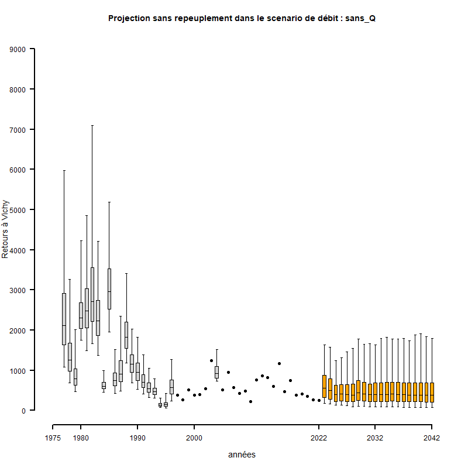

Projection à 20 ans sans repeuplement sous l’hypothèse de débits nuls

Dans ce scénario sans prise en compte de l’influence des débits sur les 20 ans de projection (débit à 0), la moyenne des adultes de retour à Vichy durant les 5 dernières années de la période de projection est de :

```
## [1] 540
```

### Projection à 20 ans pour le modèle n’incluant pas de distribution de mélange à Vichy

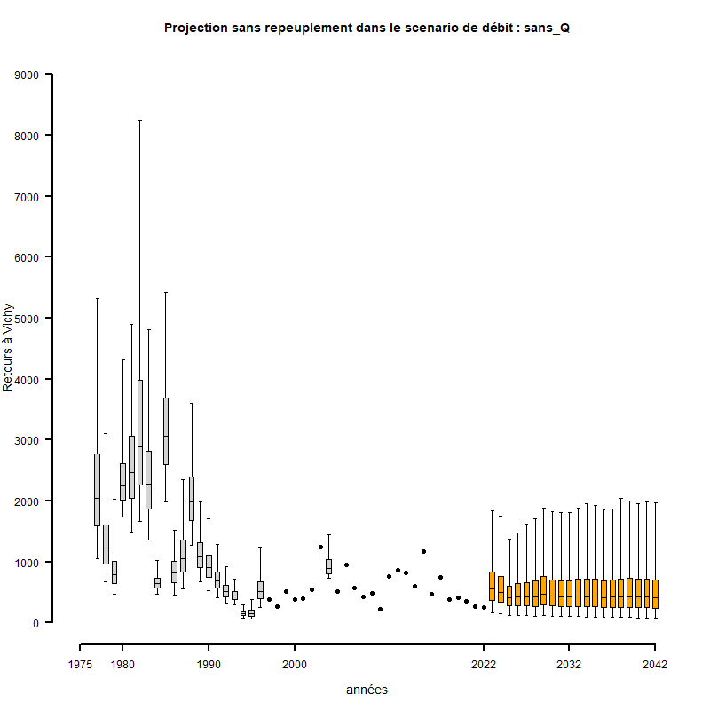

Projection à 20 ans sans repeuplement sous l’hypothèse de débits nuls - Modèle sans distribution de mélange à Vichy

Dans ce scénario sans prise en compte de l’influence des débits sur les 20 ans de projection (débit à 0), la moyenne des adultes de retour à Vichy durant les 5 dernières années de la période de projection est de :

```
## [1] 578
```

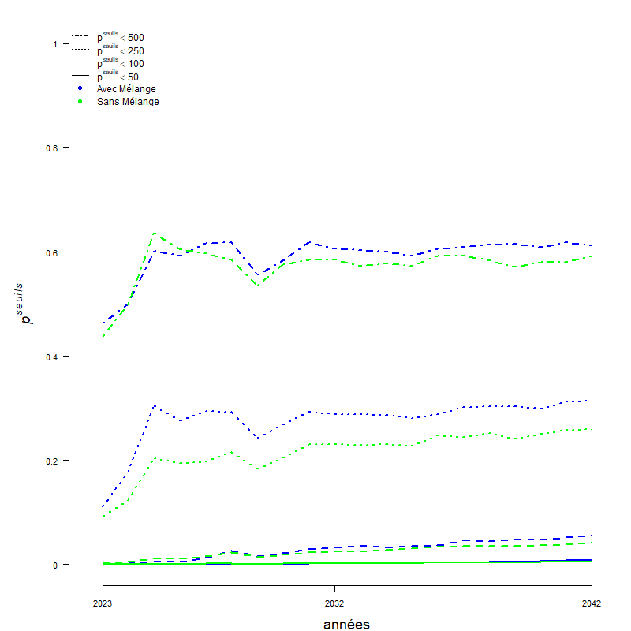

Comparaison de la probabilité d’observer moins d’un certain nombre d’individus à Vichy entre les modèles avec et sans modèle de mélange pour le scénario de débit sans_Q

## Scénario de débit “identique”

### Projection à 20 ans pour le modèle incluant la distribution de mélange à Vichy

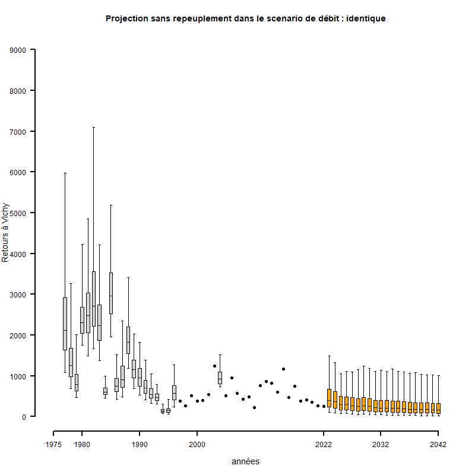

Projection à 20 ans sans repeuplement sous l’hypothèse de débits identiques à ceux observés durant les 20 dernières années de la période rétrospective

Dans ce scénario de débits identiques à ce qui a été observé durant les 20 dernières années de la période rétrospective, la moyenne des adultes de retour à Vichy durant les 5 dernières années de la période de projection est de :

```
## [1] 268
```

### Projection à 20 ans pour le modèle n’incluant pas de distribution de mélange à Vichy

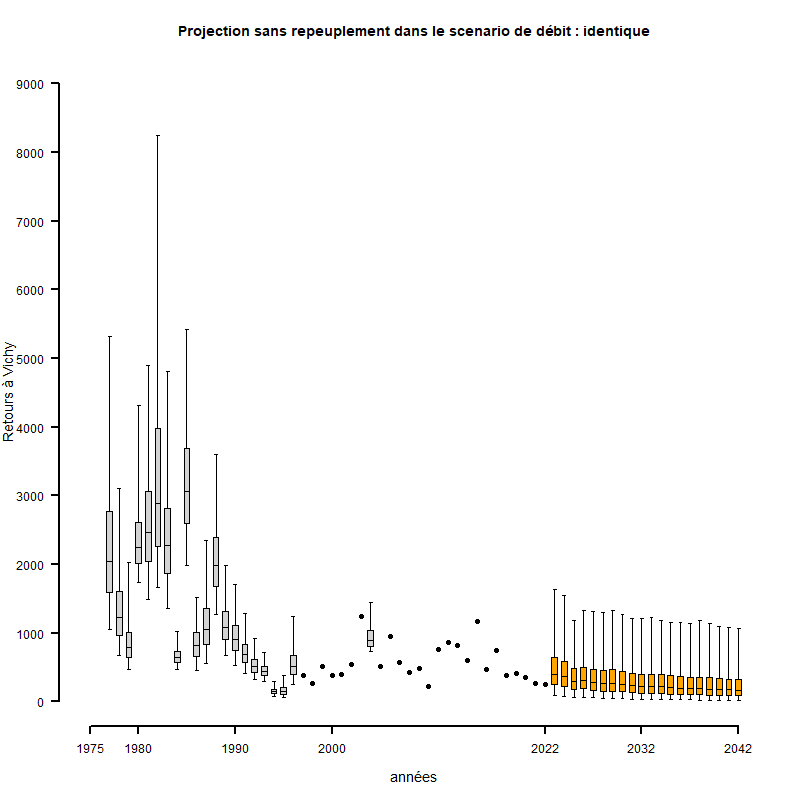

Projection à 20 ans sans repeuplement sous l’hypothèse de débits identiques à ceux observés durant les 20 dernières années de la période rétrospective - Modèle sans distribution de mélange à Vichy

Dans ce scénario de débits identiques à ce qui a été observé durant les 20 dernières années de la période rétrospective, la moyenne des adultes de retour à Vichy durant les 5 dernières années de la période de projection est de :

```
## [1] 278
```

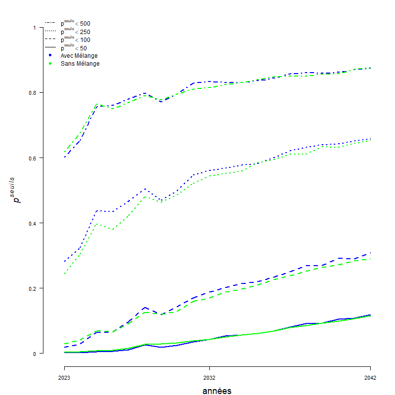

Comparaison de la probabilité d’observer moins d’un certain nombre d’individus à Vichy entre les modèles avec et sans modèle de mélange pour le scénario de débit identique

## Scénario de débit “diminue_5”

### Projection à 20 ans pour le modèle incluant la distribution de mélange à Vichy

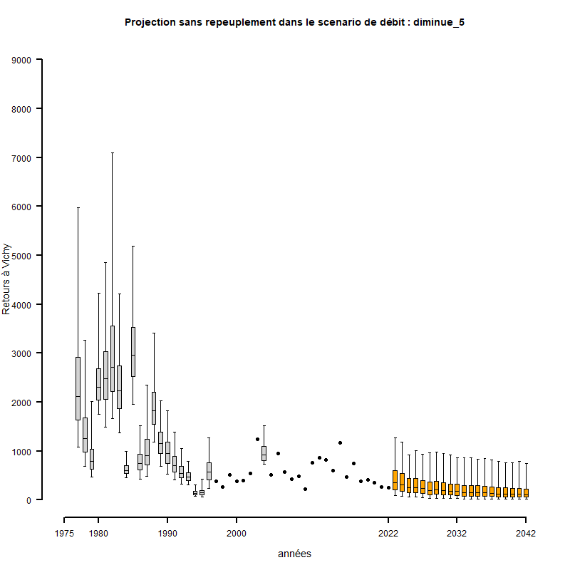

Projection à 20 ans sans repeuplement sous l’hypothèse de débits en diminution de 5% par rapport à ceux observés durant les 20 dernières années de la période rétrospective

Dans ce scénario de débits en diminution de 5% par rapport aux débits observés durant les 20 dernières années de la période rétrospective, la moyenne des adultes de retour à Vichy durant les 5 dernières années de la période de projection est de :

```
## [1] 192
```

### Projection à 20 ans pour le modèle n’incluant pas de distribution de mélange à Vichy

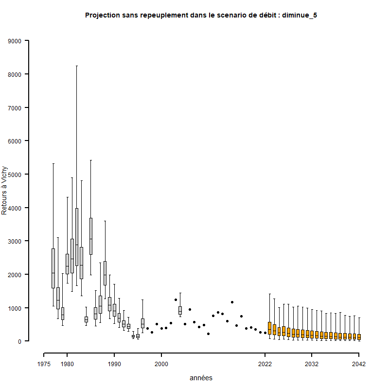

Projection à 20 ans sans repeuplement sous l’hypothèse de débits en diminution de 5% par rapport à ceux observés durant les 20 dernières années de la période rétrospective - Modèle sans distribution de mélange à Vichy

Dans ce scénario de débits en diminution de 5% par rapport aux débits observés durant les 20 dernières années de la période rétrospective, la moyenne des adultes de retour à Vichy durant les 5 dernières années de la période de projection est de :

```
## [1] 187
```

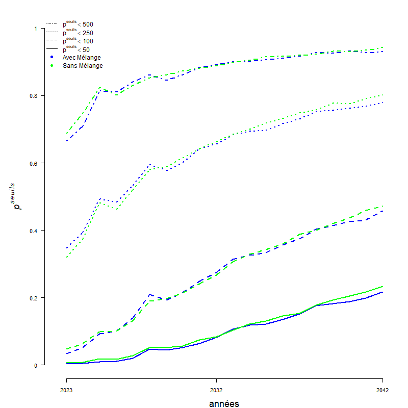

Comparaison de la probabilité d’observer moins d’un certain nombre d’individus à Vichy entre les modèles avec et sans modèle de mélange pour le scénario de débit diminue_5

## Scénario de débit “diminue_10”

### Projection à 20 ans pour le modèle incluant la distribution de mélange à Vichy

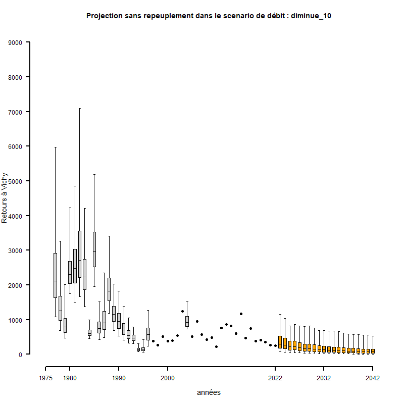

Projection à 20 ans sans repeuplement sous l’hypothèse de débits en diminution de 10% par rapport à ceux observés durant les 20 dernières années de la période rétrospective

Dans ce scénario de débits en diminution de 10% par rapport aux débits observés durant les 20 dernières années de la période rétrospective, la moyenne des adultes de retour à Vichy durant les 5 dernières années de la période de projection est de :

```
## [1] 131
```

### Projection à 20 ans pour le modèle n’incluant pas de distribution de mélange à Vichy

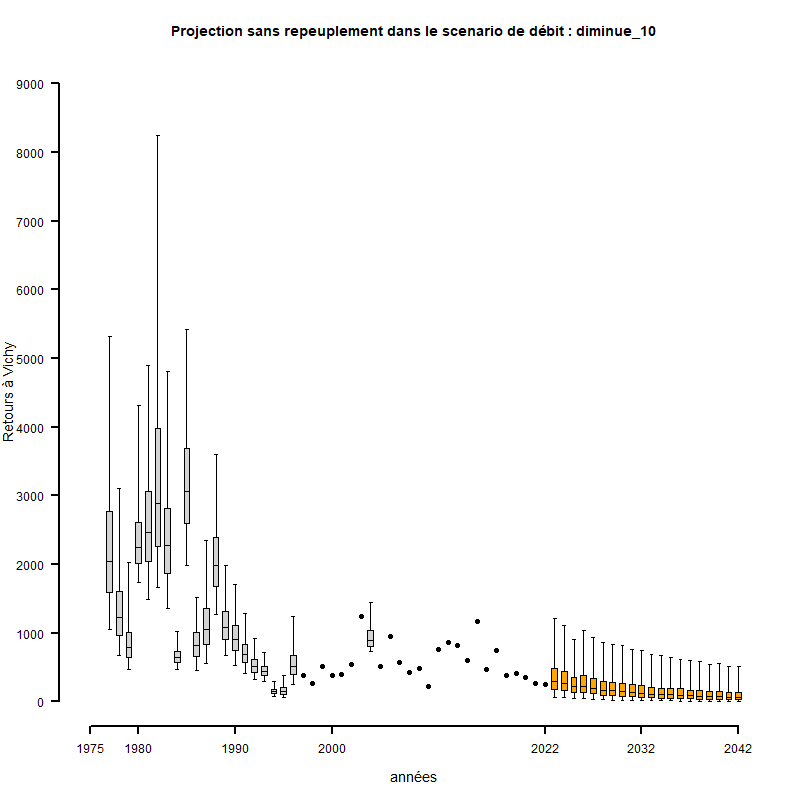

Projection à 20 ans sans repeuplement sous l’hypothèse de débits en diminution de 10% par rapport à ceux observés durant les 20 dernières années de la période rétrospective - Modèle sans distribution de mélange à Vichy

Dans ce scénario de débits en diminution de 10% par rapport aux débits observés durant les 20 dernières années de la période rétrospective, la moyenne des adultes de retour à Vichy durant les 5 dernières années de la période de projection est de :

```
## [1] 122
```

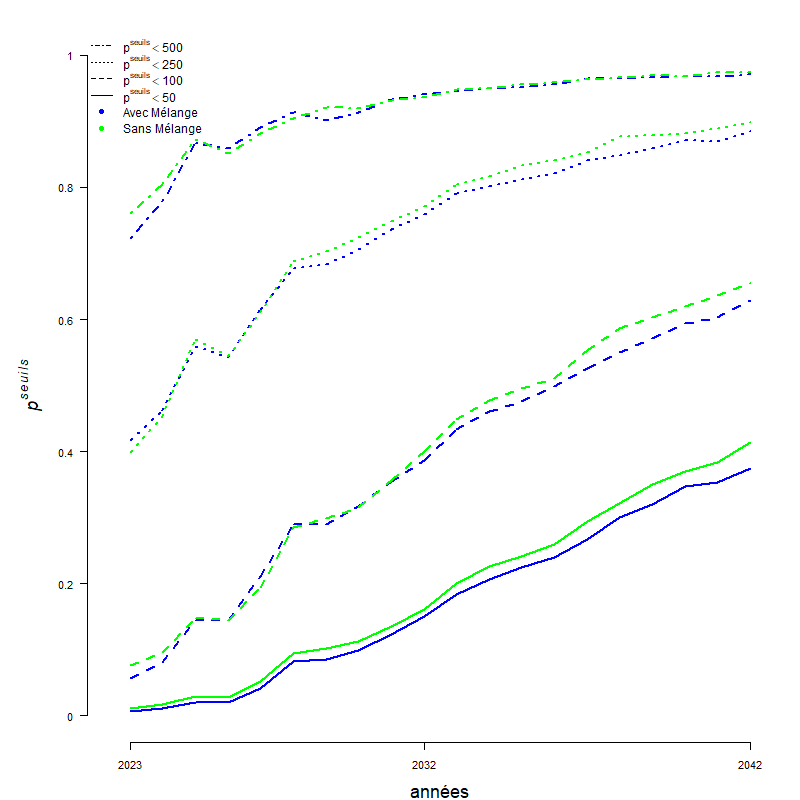

Comparaison de la probabilité d’observer moins d’un certain nombre d’individus à Vichy entre les modèles avec et sans modèle de mélange pour le scénario de débit diminue_10

## Comparaison des scénarios

### Seuil 50 individus à Vichy

#### Modèle avec mélange

[figure not shown]

#### Modèle sans mélange

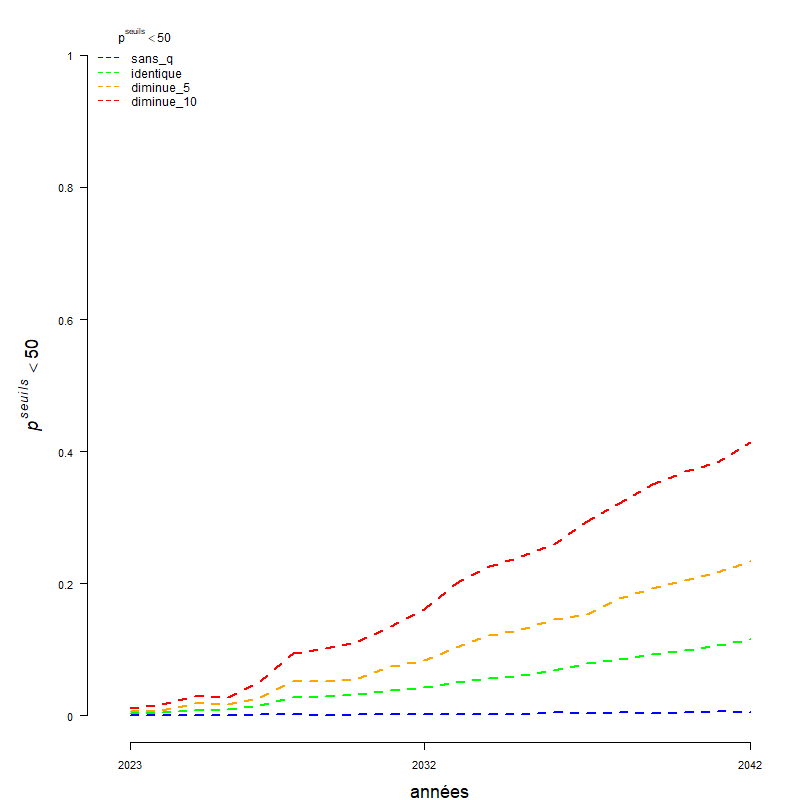

### Seuil 100 individus à Vichy

#### Modèle avec mélange

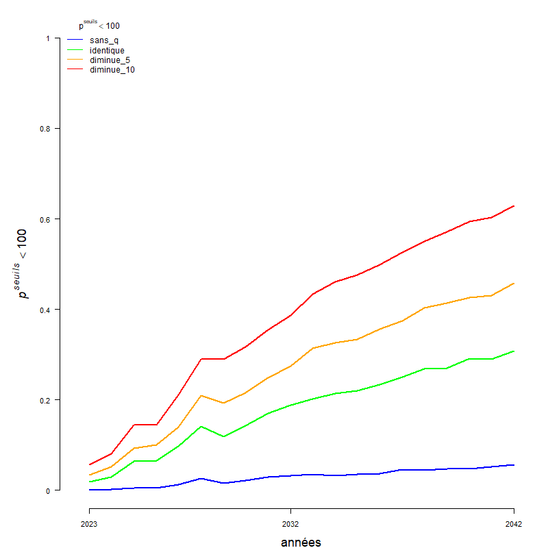

#### Modèle sans mélange

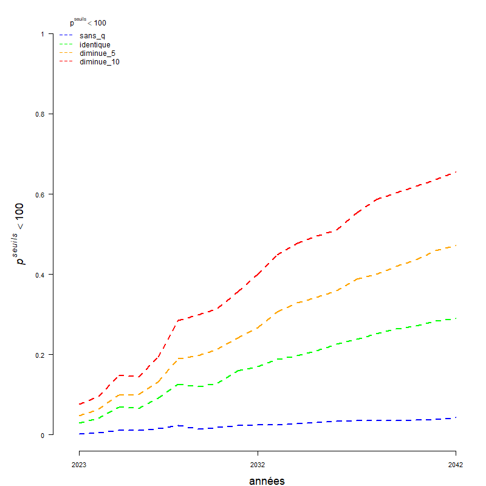

### Seuil 250 individus à Vichy

#### Modèle avec mélange

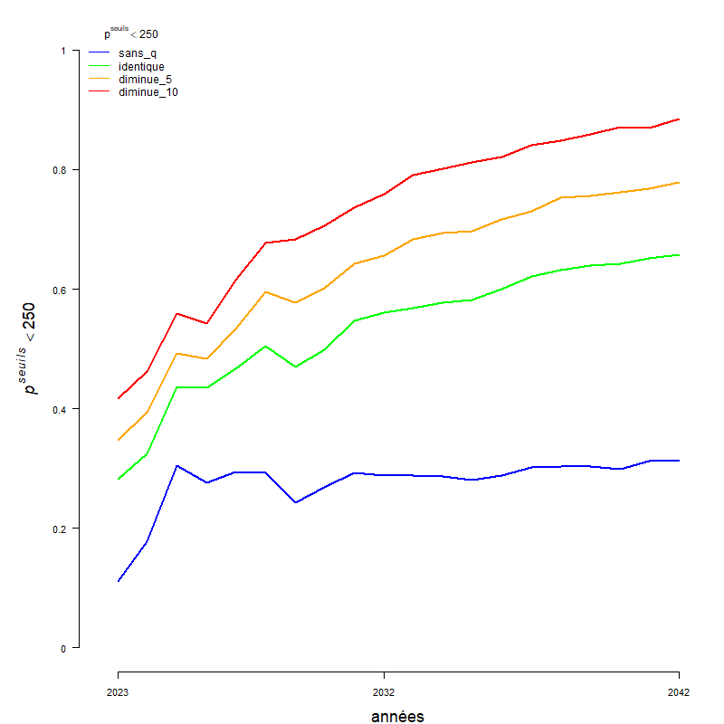

#### Modèle sans mélange

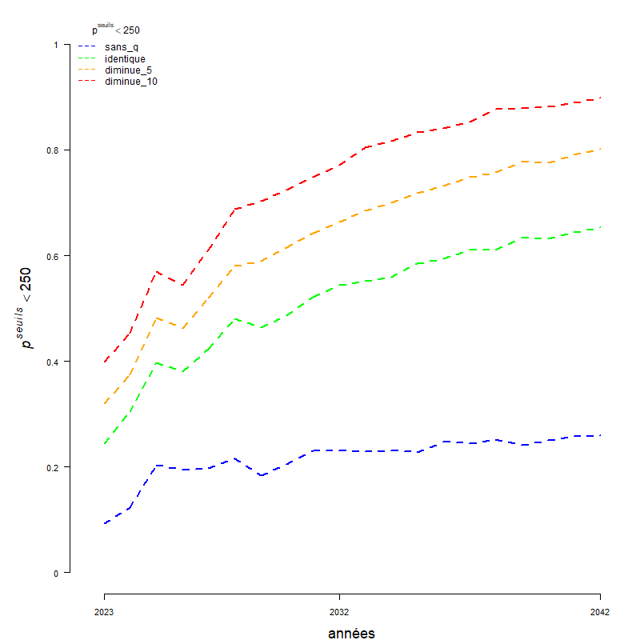

### Seuil 500 individus à Vichy

#### Modèle avec mélange

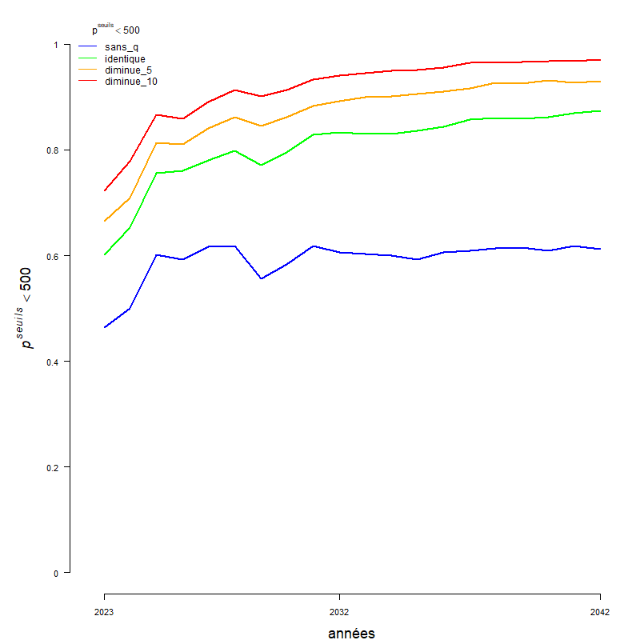

#### Modèle sans mélange

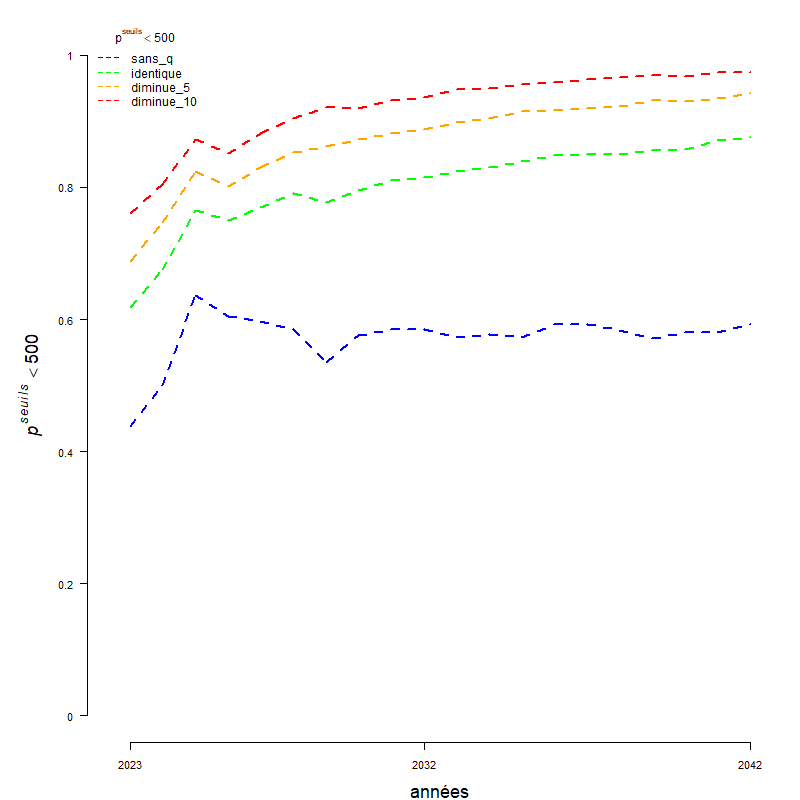